# Data Squad Technical Test

Stewart Li

4/7/2021

*Source:* [*Data Squad Technical Test*](https://github.com/cdg-data-coe/interviews2)

## Context

Under each transport commercial contract, there may be multiple, dynamic bookings per month. There is opportunity to automate and optimise transportation planning i.e. match vehicles to schedule.

The goal is to allocate the minimum number of vehicles, (and cost - larger cacpacity bus cost more) to each commercial contract for that 1 month.

Each trip journey, and each bus total journey **cannot exceed 45mins**. There are 10, 19 and 40-seater buses that can be utilised.

### Task

1. Perform a EDA on the excel sheet named- ‘input’ using MS Power BI.
2. Then, write a Python program to generate the ‘output_plan’ excel sheet.
3. Ensure the code / model can run on other scenario inputs with same data attributes.
4. State your assumptions clearly.

### Important Instructions

1. Implement the task, comment your codes and commit into github.
2. Write clear steps for evaluators to setup and run your codes.
3. Include comments on how your solution solves the problem and possible enhancement if given more time and data (what kind of data).

## My solution

Assumptions;

1. I am unable to find information about the column of `10, 19 and 40-seater buses`. Therefore, I can not do calculation (or model) on it.
2. Columns of `pickup_time` and `dropoff_time` contain missing values. I remove them in order to calculate travel time.
3. The columns of `bookiing_id` is unique (no duplication), which seems different from the question statement (The goal is to allocate the minimum number of vehicles to each commercial contract for that 1 month). It would be helpful if there are more details in this regards.

Notes;

1. I use `R` to perform EDA instead of `MS Power BI`.
2. It is very easy to write out excel sheet in `R`. Thus, it is not necessary for me to jump into `Python` to do it.
3. My result is the `stewartli` (sheetname) of excel workbook. HTML version of this document is attached for your review.
4. I have refactored my code to ensure it runs for other similar data.

### Import data

```
> Rows: 1,277
> Columns: 7
> $ `Booking ID`                          <chr> "AD-674", "AD-840", "AD-1136"...
> $ `Journey Date`                        <chr> "01 Mar 2021", "01 Mar 2021",...
> $ `Pickup Time`                         <chr> "--:--", "--:--", "04:28 AM",...
> $ `Dropoff Time`                        <chr> "05:30 AM", "05:30 AM", "05:3...
> $ `Booking Status`                      <chr> "Cancelled", "Cancelled", "Co...
> $ `Pickup Address from Google Map`      <chr> "122A Sengkang E Way, Singapo...
> $ `Destination Address from Google Map` <chr> "Beach Station, Singapore", "...
```

### Clean data

```
> # A tibble: 6 x 10
>   booking_id journey    pickup dropoff journey_date pickup_time dropoff_time
>   <chr>      <date>     <chr>  <chr>   <chr>        <chr>       <chr>
> 1 AD-674     2021-03-01 01 Ma~ 01 Mar~ 01 Mar 2021  <NA>        05:30 AM
> 2 AD-840     2021-03-01 01 Ma~ 01 Mar~ 01 Mar 2021  <NA>        05:30 AM
> 3 AD-1136    2021-03-01 01 Ma~ 01 Mar~ 01 Mar 2021  04:28 AM    05:30 AM
> 4 AD-1146    2021-03-01 01 Ma~ 01 Mar~ 01 Mar 2021  <NA>        05:30 AM
> 5 AD-1175    2021-03-01 01 Ma~ 01 Mar~ 01 Mar 2021  <NA>        05:30 AM
> 6 AD-1235    2021-03-01 01 Ma~ 01 Mar~ 01 Mar 2021  <NA>        05:30 AM
> # ... with 3 more variables: booking_status <chr>,
> #   pickup_address_from_google_map <chr>,
> #   destination_address_from_google_map <chr>
```

### EDA

Data summary

| Name | df_clean |
| --- | --- |
| Number of rows | 1277 |
| Number of columns | 10 |
| _______________________ |  |
| Column type frequency: |  |
| character | 9 |
| Date | 1 |
| ________________________ |  |
| Group variables | None |

**Variable type: character**

| skim_variable | n_missing | complete_rate | min | max | empty | n_unique | whitespace |
| --- | --- | --- | --- | --- | --- | --- | --- |
| booking_id | 0 | 1.00 | 6 | 7 | 0 | 1277 | 0 |
| pickup | 0 | 1.00 | 17 | 20 | 0 | 421 | 0 |
| dropoff | 0 | 1.00 | 17 | 20 | 0 | 364 | 0 |
| journey_date | 0 | 1.00 | 11 | 11 | 0 | 31 | 0 |
| pickup_time | 527 | 0.59 | 8 | 8 | 0 | 79 | 0 |
| dropoff_time | 182 | 0.86 | 8 | 8 | 0 | 64 | 0 |
| booking_status | 0 | 1.00 | 3 | 9 | 0 | 3 | 0 |
| pickup_address_from_google_map | 0 | 1.00 | 16 | 67 | 0 | 81 | 0 |
| destination_address_from_google_map | 0 | 1.00 | 16 | 67 | 0 | 75 | 0 |

**Variable type: Date**

| skim_variable | n_missing | complete_rate | min | max | median | n_unique |
| --- | --- | --- | --- | --- | --- | --- |
| journey | 0 | 1 | 2021-03-01 | 2021-03-31 | 2021-03-14 | 31 |

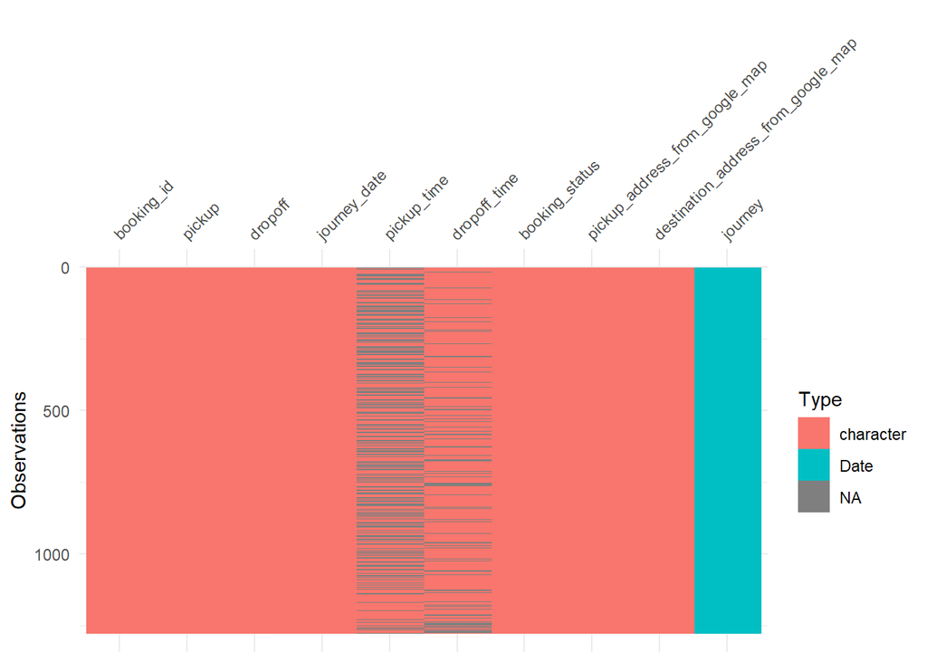

```
> # A tibble: 7 x 5
>   weekday Cancelled Confirmed   New pct_cancel
>   <ord>       <int>     <int> <int>      <dbl>
> 1 Sun            88        83     1      0.512
> 2 Mon           112       104     2      0.514
> 3 Tue           108        86    20      0.505
> 4 Wed            97        74    12      0.530
> 5 Thu            92        67     1      0.575
> 6 Fri            91        78     0      0.538
> 7 Sat            85        76     0      0.528
```

### Write excel

```
> # A tibble: 6 x 4
>   journey    type_of_bus_10_19_40_seaters travel  booking_ids
>   <date>                            <dbl> <drtn>  <chr>
> 1 2021-03-01                           10 13 mins AD-1285
> 2 2021-03-01                           10 17 mins AD-1278
> 3 2021-03-01                           10 19 mins AD-1308
> 4 2021-03-01                           10 27 mins AD-828
> 5 2021-03-01                           10 30 mins AD-1310
> 6 2021-03-01                           10 34 mins AD-1279
```